# Time Series Analysis Assignment 3

Gavin Connolly

15/11/2021

Read in the 3 time series in the file “assignment3.csv” using series=read.csv(‘assignment3.csv’) and answer the following questions.

```r
series=read.csv('assignment3.csv')
X = series[,1]
Y = series[,2]
Z = series[,3]
```

## Exercise 1

#### a) For Series X, identify the number of differences (if any) and order of the ARMA model for the stationary series based on the results of tsdisplay(). Give reasons for your answers.

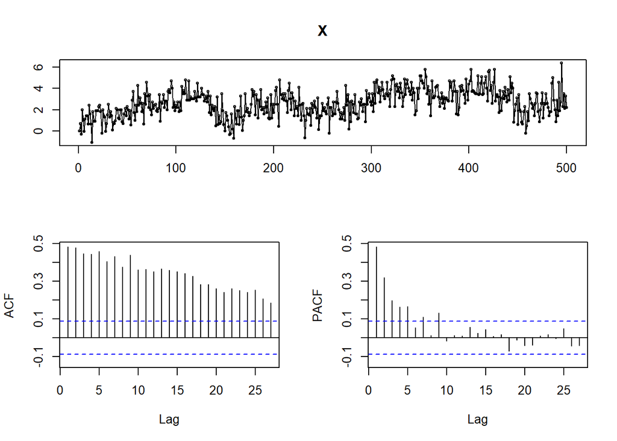

```r
tsdisplay(X) # ACF & PACF decay slowly indicating our time series is integrated
```

As the ACF seems to be decaying linearly & both ACF/PACF decay slowly, we conclude that the time series is integrated. We therefore look to difference the series before continuing.

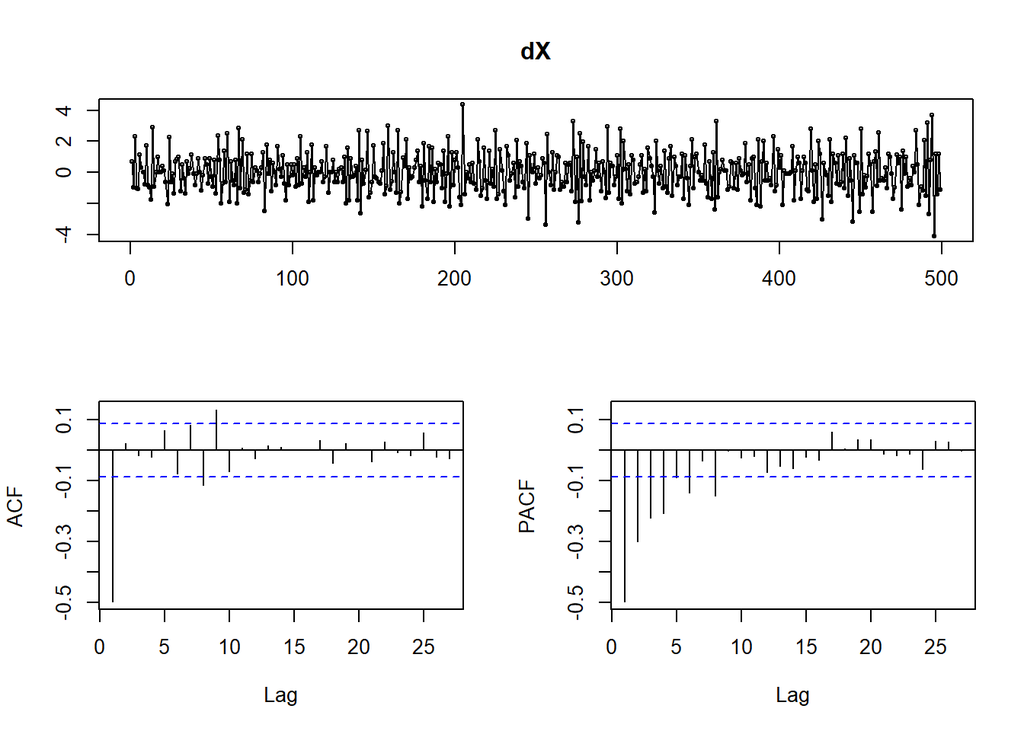

```r
dX = diff(X)
tsdisplay(dX)
```

```r
# ACF null after lag of 1. PACF decays exponentially.
# dX is MA(1). with theta roughly equal to 0.5
# X is ARIMA(0, 1, 1)
```

We see that the ACF plot of the integrated series dX is null after a lag of 1, while the PACF decays exponentially, indicating that the differenced series is ARMA(0, 1).

We thus conclude that Series X is generated by an ARIMA(0, 1, 1) model.

#### b) For Series Y, identify the number of differences (if any) and order of the ARMA model for the stationary series based on the results of tsdisplay(). Give reasons for your answers.

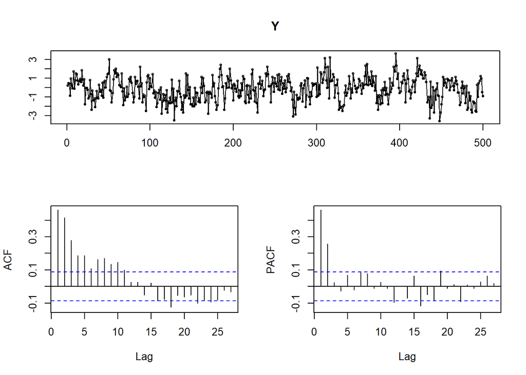

```r
tsdisplay(Y)
```

We see that the ACF plot for Y decays exponentially while the PACF is null after a lag of 2. As neither the ACF/PACF plots decay linearly we know the series is not integrated.

We therefore conclude that the series is AR(2).

#### c) Report the AR and/or MA parameter estimates for Series X and Y, with no drift by using include.mean=FALSE. Are they statistically significant?

```r
modelX = arima(X, order = c(0,1,1), include.mean = FALSE)
coeftest(modelX)
```

```
##
## z test of coefficients:
##
##      Estimate Std. Error z value  Pr(>|z|)
## ma1 -0.824827   0.025328 -32.565 < 2.2e-16 ***
## ---
## Signif. codes:  0 '***' 0.001 '**' 0.01 '*' 0.05 '.' 0.1 ' ' 1
```

```r
# Pr(>|Z|) = 2.2e-16, so parameter estimate is significant.
```

We calculate $\theta_1$ to be -0.8248, with a p-value of 0. We therefore conclude that the model parameters are significant.

```r
modelY = arima(Y, order = c(2,0,0), include.mean = FALSE)
coeftest(modelY)
```

```
##
## z test of coefficients:
##
##     Estimate Std. Error z value  Pr(>|z|)
## ar1 0.347070   0.043090  8.0545 7.983e-16 ***
## ar2 0.260208   0.043091  6.0386 1.555e-09 ***
## ---
## Signif. codes:  0 '***' 0.001 '**' 0.01 '*' 0.05 '.' 0.1 ' ' 1
```

```r
# Pr(>|phi1|) = 7.9833e-16 & Pr(>|phi2|) = 1.55e-09, so parameter estimates are significant.
```

We calculate $\phi_1$ to be 0.3471 & $\phi_2$ to be 0.2602, with a p-value of roughly 0 for each. We therefore conclude that each of the model parameters are significant.

#### d) Look at Series Z. What type of model should you choose and why? Again, focus on models without drift (i.e. mean zero).

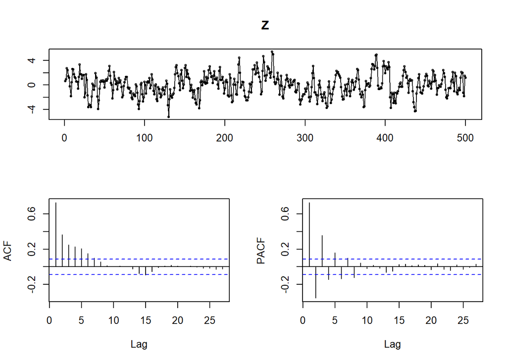

```r
tsdisplay(Z)
```

ACF/PACF plots for Z both tail off, indicating that we should use an ARMA process for the time series.

#### e) Now try ARMA(1,1), ARMA(1,2) and ARMA(2,1) models fit to Series Z. Do the parameters come out to be statistically significant? Why?

```r
modelZ1 = arima(Z, order = c(1, 0, 1), include.mean = FALSE)
coeftest(modelZ1) # coefficients are significant
```

```
##
## z test of coefficients:
##
##     Estimate Std. Error z value  Pr(>|z|)
## ar1 0.456554   0.042733  10.684 < 2.2e-16 ***
## ma1 0.804087   0.027625  29.108 < 2.2e-16 ***
## ---
## Signif. codes:  0 '***' 0.001 '**' 0.01 '*' 0.05 '.' 0.1 ' ' 1
```

Coefficients for the ARMA(1,1) model are all significant.

```r
modelZ2 = arima(Z, order = c(1, 0, 2), include.mean = FALSE)
coeftest(modelZ2) #AR1 & MA1 coefficients are significant, MA2 coefficient is not significant
```

```
##
## z test of coefficients:
##
##      Estimate Std. Error z value  Pr(>|z|)
## ar1  0.527975   0.123222  4.2847 1.830e-05 ***
## ma1  0.717124   0.148199  4.8389 1.305e-06 ***
## ma2 -0.082674   0.138975 -0.5949    0.5519
## ---
## Signif. codes:  0 '***' 0.001 '**' 0.01 '*' 0.05 '.' 0.1 ' ' 1
```

$\phi_1$ & $\theta_1$ coefficients for the ARMA(1,2) model are significant, while the $\theta_2$ coefficient is not significant. This is because the model is overfitting the data, meaning that the parameter is not needed in the model, and therefore its value is not significantly different from 0.

```r
modelZ3 = arima(Z, order = c(2, 0, 1), include.mean = FALSE)
coeftest(modelZ3) # AR1 & MA1 coefficients are significant, AR2 coefficient is not significant
```

```
##
## z test of coefficients:
##
##     Estimate Std. Error z value  Pr(>|z|)
## ar1 0.441360   0.055377  7.9700 1.586e-15 ***
## ar2 0.023233   0.054056  0.4298    0.6673
## ma1 0.811964   0.032237 25.1876 < 2.2e-16 ***
## ---
## Signif. codes:  0 '***' 0.001 '**' 0.01 '*' 0.05 '.' 0.1 ' ' 1
```

```r
# We get significant coefficients for AR1 & MA1 terms as the time series is generated by an ARMA(1,1)
# We get non-significant coefficients for the AR2 & MA2 terms as they overfit the model, meaning they are not significantly different from 0
```

Once again, the $\phi_1$ & $\theta_1$ coefficients for the ARMA(2,1) model are significant, but the $\phi_2$ coefficient is not significant. This is because the model is overfitting the data, meaning that the parameter is not needed in the model, and therefore its value is not significantly different from 0.

## Exercise 2

We will now examine model fit for Series Z in more detail.

#### a) Examine the residuals of an ARMA(1,1) model fit to Series Z and describe what you find.

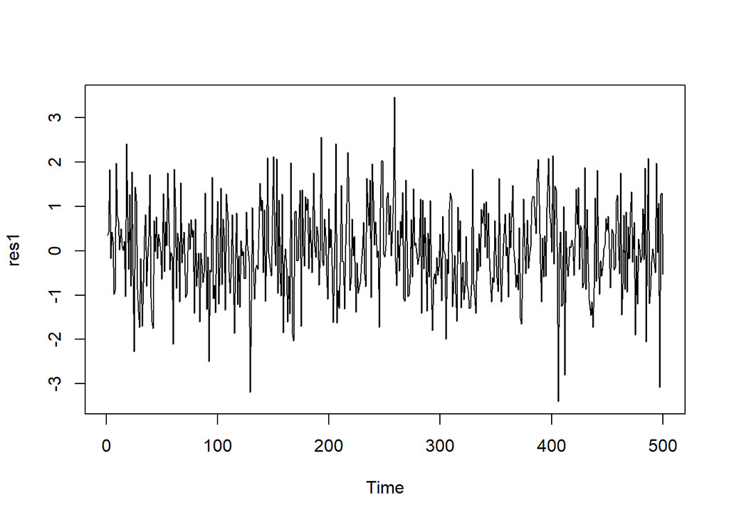

```r
res1 = residuals(modelZ1)
plot(res1)
```

```r
mean(res1)
```

```
## [1] 0.01344854
```

```r
var(res1)
```

```
## [1] 1.036606
```

Plot of residuals looks to be distributed as a white noise. Mean of residuals roughly 0 & variance roughly 1.

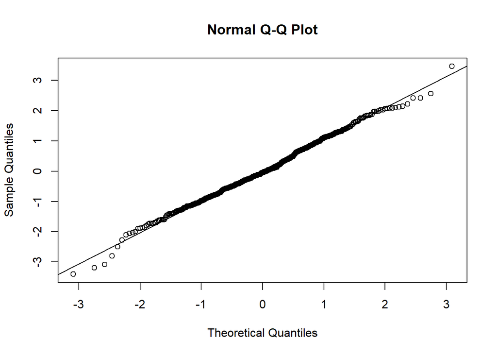

```r
qqnorm(res1)
qqline(res1)
```

```r
shapiro.test(res1)
```

```
##
##  Shapiro-Wilk normality test
##
## data:  res1
## W = 0.9958, p-value = 0.2032
```